# creditcard_segmentation

## K -means clustering

```python
# create clusters

clusters = range(1,10)
distortion = []

for k in clusters:
    model=KMeans(n_clusters=k)
    model.fit(creditdata_scale)
    distortion.append(model.inertia_)
```

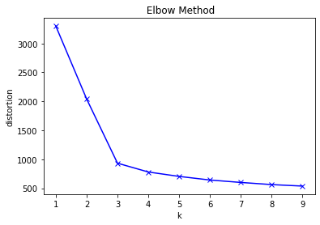

```python
from matplotlib import cm

plt.plot(clusters, distortion, 'bx-')
plt.xlabel('k')
plt.ylabel('distortion')
plt.title(' Elbow Method')
```

```python
# We could see the bend at 3, so create 3 custers
kmeans = KMeans(n_clusters=3, n_init = 5, random_state=1)
kmeans.fit(creditdata_scale)
```

```
KMeans(n_clusters=3, n_init=5, random_state=1)
```

```python
# check the centers in each group
centroids = kmeans.cluster_centers_
centroid_df = pd.DataFrame(centroids, columns = list(creditdata_scale) )
centroid_df
```

|  | Avg_Credit_Limit | Total_Credit_Cards | Total_visits_bank | Total_visits_online | Total_calls_made |
| --- | --- | --- | --- | --- | --- |
| 0 | -0.595796 | -1.059623 | -0.901518 | 0.322997 | 1.148109 |
| 1 | -0.021062 | 0.373690 | 0.666395 | -0.553672 | -0.553005 |
| 2 | 2.831764 | 1.862226 | -1.105763 | 2.827319 | -0.874330 |

```python
## creating a new dataframe only for labels and converting it into categorical variable
df_labels = pd.DataFrame(kmeans.labels_ , columns = list(['labels']))
df_labels['labels'] = df_labels['labels'].astype('category')
label_k=kmeans.labels_
#label_k
```

```python
# Joining the label dataframe with the scaled data frame.
df_labeled = creditdata_scale.join(df_labels)
df_labeled.head(5)
```

|  | Avg_Credit_Limit | Total_Credit_Cards | Total_visits_bank | Total_visits_online | Total_calls_made | labels |
| --- | --- | --- | --- | --- | --- | --- |
| 0 | 1.740187 | -1.249225 | -0.860451 | -0.547490 | -1.251537 | 1 |
| 1 | 0.410293 | -0.787585 | -1.473731 | 2.520519 | 1.891859 | 0 |
| 2 | 0.410293 | 1.058973 | -0.860451 | 0.134290 | 0.145528 | 1 |
| 3 | -0.121665 | 0.135694 | -0.860451 | -0.547490 | 0.145528 | 1 |
| 4 | 1.740187 | 0.597334 | -1.473731 | 3.202298 | -0.203739 | 2 |

```python
df_labeled['labels'].value_counts()
```

```
1    386
0    224
2     50
Name: labels, dtype: int64
```

```
array([[<matplotlib.axes._subplots.AxesSubplot object at 0x000001AEFC2F4580>,
      dtype=object)
```

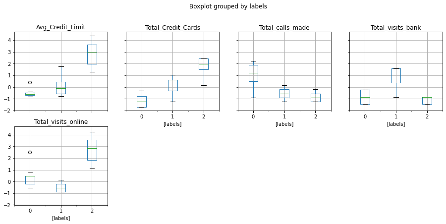

```python
df_labeled.boxplot(by = 'labels',  layout=(3,4), figsize=(15, 10))
```

```python
# Joining the label dataframe with the original data frame.
df_labeled_orig = creditdata.join(df_labels)
df_labeled_orig.groupby('labels').mean()
```

| labels | Avg_Credit_Limit | Total_Credit_Cards | Total_visits_bank | Total_visits_online | Total_calls_made |
| --- | --- | --- | --- | --- | --- |
| 0 | 12174.107143 | 2.410714 | 0.933036 | 3.553571 | 6.870536 |
| 1 | 33782.383420 | 5.515544 | 3.489637 | 0.981865 | 2.000000 |
| 2 | 141040.000000 | 8.740000 | 0.600000 | 10.900000 | 1.080000 |

### Observations :

Cluster 0 is characterised by lower credit limit , low # of credit cards, medium bank visit ,medium online visit , high calls

Cluster 1 is characterised by medium credit limit , medium # of credit cards, high bank visit , low online visit , medium calls

Cluster 2 is characterised by high credit limit , high # of credit cards, low bank visit , high online visit , low calls

### Key Questions:

1) How many different segments of customers are there?

```
 Based on spending pattern 3 segment of
 cluster 0--customers low spendin
 cluster 1--medium spending
 cluster 2--high spending
```

2) How are these segments different from each other?

```
 Segemnts are differnt based on there spending behaviour ,number of credit cards  and communications to bank .
```

3) What are your recommendations to the bank on how to better market to and service these customers?

```
 Cluster 0 -- Bank can provide new offer so customers in this segment use the credit card more often on purchases ,use  phone calls as means of marketing.
 Cluster 1 --May be a cash back will encourage these segement of customers to use credit card more ,marketing can be
 done  when they visit bank.
 Cluster 2-- loyalty programs may help bank to keep these customers for long time ,means of marketing is thru online
```

```python
from sklearn.metrics import silhouette_score
silhouette_score(creditdata_scale,label_k)
```

```
0.5157182558881063
```

```python
#Silhouette Score is better when closer 1 and worse when closer to -1. So 0.51 is good score
```

## Hierarchical clustering

```python
from scipy.spatial.distance import pdist
from scipy.cluster.hierarchy import dendrogram, linkage ,cophenet
```

```python
pos = 1
linkage_methods = [ 'ward', 'single', 'complete','average', 'weighted','centroid', 'median']
for i in linkage_methods:
    datalink = linkage(creditdata_scale, i, metric='euclidean')
    datalink_coph_i=cophenet(datalink,pdist(creditdata_scale))[0]
    print('cophenet',i,':',datalink_coph_i)
    pos += 1  # to plot over the grid one by one
```

```
cophenet ward : 0.7415156284827493
cophenet single : 0.7391220243806552
cophenet complete : 0.8599730607972423
cophenet average : 0.8977080867389372
cophenet weighted : 0.8861746814895477
cophenet centroid : 0.8939385846326323
cophenet median : 0.8893799537016724
```

### Linkage by Ward method

```
cophenet 0.7415156284827493
```

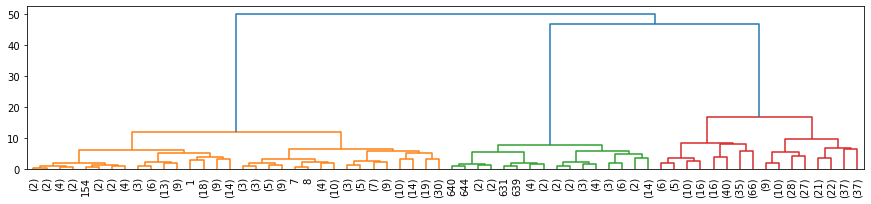

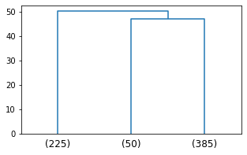

```python
datalink = linkage(creditdata_scale, 'ward', metric='euclidean')
datalink_coph=cophenet(datalink,pdist(creditdata_scale))[0]
print('cophenet',datalink_coph)
plt.figure(figsize=(15, 3))
dendrogram(datalink,leaf_rotation=90.0,p=5,leaf_font_size=10,truncate_mode='level')
plt.show()
plt.figure(figsize=(5, 3))
dendrogram(datalink,truncate_mode='lastp',p=3)
plt.show()
```

```python
from scipy.cluster.hierarchy import fcluster
max_d = 3
labels_h = fcluster(datalink_a, max_d, criterion='distance')
#labels_h
## creating a new dataframe only for labels and converting it into categorical variable
df_labels_h = pd.DataFrame(labels_h , columns = list(['labels']))
df_labels_h['labels'] = df_labels_h['labels'].astype('category')
# Joining the label dataframe with the scaled data frame.
df_labeled_h = creditdata_scale.join(df_labels_h)
#df_labeled_h.head(5)
# Joining the label dataframe with the original data frame.
df_labeled_orig_h = creditdata.join(df_labels_h)
#df_labeled_orig_h.head(5)
df_labeled_h['labels'].value_counts()
df_labeled_h.boxplot(by = 'labels',  layout=(3,4), figsize=(15, 10))
```

```
array([[<matplotlib.axes._subplots.AxesSubplot object at 0x000001AEFC1F2880>,
      dtype=object)
```

```python
silhouette_s=silhouette_score(creditdata_scale,labels_h)
print('silhouette_s',silhouette_s)
```

```
silhouette_s 0.47495143595793504
```

### Linkage by single method

```
cophenet 0.7391220243806552
```

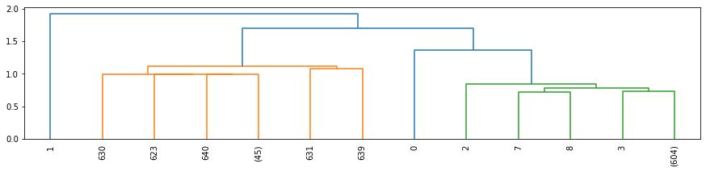

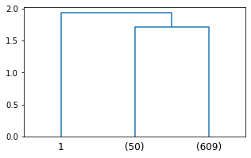

```python
datalink = linkage(creditdata_scale, 'single', metric='euclidean')
datalink_coph=cophenet(datalink,pdist(creditdata_scale))[0]
print('cophenet',datalink_coph)
plt.figure(figsize=(15, 3))
dendrogram(datalink,leaf_rotation=90.0,p=5,leaf_font_size=10,truncate_mode='level')
plt.show()
plt.figure(figsize=(5, 3))
dendrogram(datalink,truncate_mode='lastp',p=3)
plt.show()
```

```
array([[<matplotlib.axes._subplots.AxesSubplot object at 0x000001AEF98B4400>,
      dtype=object)
```

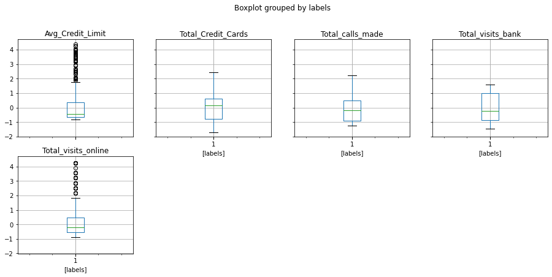

```python
from scipy.cluster.hierarchy import fcluster
max_d = 10
labels_h = fcluster(datalink_a, max_d, criterion='distance')
labels_h
## creating a new dataframe only for labels and converting it into categorical variable
df_labels_h = pd.DataFrame(labels_h , columns = list(['labels']))
df_labels_h['labels'] = df_labels_h['labels'].astype('category')
# Joining the label dataframe with the scaled data frame.
df_labeled_h = creditdata_scale.join(df_labels_h)
#df_labeled_h.head(5)
# Joining the label dataframe with the original data frame.
df_labeled_orig_h = creditdata.join(df_labels_h)
#df_labeled_orig_h.head(5)
df_labeled_h['labels'].value_counts()

df_labeled_h.boxplot(by = 'labels',  layout=(3,4), figsize=(15, 10))
```

#### Observation : single cluster ,so not using this method

### Linkage by Complete method

```
cophenet 0.8599730607972423
```

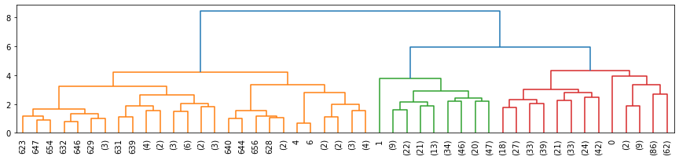

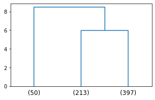

```python
datalink = linkage(creditdata_scale, 'complete', metric='euclidean')
datalink_coph=cophenet(datalink,pdist(creditdata_scale))[0]
print('cophenet',datalink_coph)
plt.figure(figsize=(15, 3))
dendrogram(datalink,leaf_rotation=90.0,p=5,leaf_font_size=10,truncate_mode='level')
plt.show()
plt.figure(figsize=(5, 3))
dendrogram(datalink,truncate_mode='lastp',p=3)
plt.show()
```

```
array([[<matplotlib.axes._subplots.AxesSubplot object at 0x000001AEFBE46A90>,
      dtype=object)
```

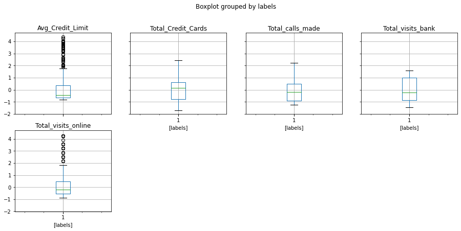

```python
from scipy.cluster.hierarchy import fcluster
max_d = 10
labels_h = fcluster(datalink_a, max_d, criterion='distance')
labels_h
## creating a new dataframe only for labels and converting it into categorical variable
df_labels_h = pd.DataFrame(labels_h , columns = list(['labels']))
df_labels_h['labels'] = df_labels_h['labels'].astype('category')
# Joining the label dataframe with the scaled data frame.
df_labeled_h = creditdata_scale.join(df_labels_h)
#df_labeled_h.head(5)
# Joining the label dataframe with the original data frame.
df_labeled_orig_h = creditdata.join(df_labels_h)
#df_labeled_orig_h.head(5)
df_labeled_h['labels'].value_counts()

df_labeled_h.boxplot(by = 'labels',  layout=(3,4), figsize=(15, 10))
```

#### Observation : single cluster ,so not using this method

### Linkage by Average method

```
cophenet 0.8977080867389372
```

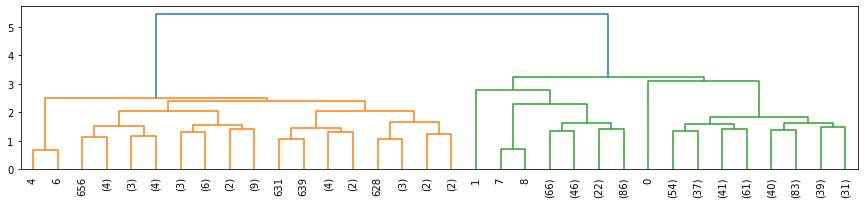

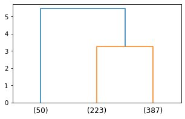

```python
#find copenet score and dendogram
datalink = linkage(creditdata_scale, 'average', metric='euclidean')
datalink_coph=cophenet(datalink,pdist(creditdata_scale))[0]
print('cophenet',datalink_coph)
plt.figure(figsize=(15, 3))
dendrogram(datalink,leaf_rotation=90.0,p=5,leaf_font_size=10,truncate_mode='level')
plt.show()
plt.figure(figsize=(5, 3))
dendrogram(datalink,truncate_mode='lastp',p=3)
plt.show()
```

```python
#analyse using box plot
from scipy.cluster.hierarchy import fcluster
max_d = 3
labels_h = fcluster(datalink_a, max_d, criterion='distance')
labels_h
## creating a new dataframe only for labels and converting it into categorical variable
df_labels_h = pd.DataFrame(labels_h , columns = list(['labels']))
df_labels_h['labels'] = df_labels_h['labels'].astype('category')
# Joining the label dataframe with the scaled data frame.
df_labeled_h = creditdata_scale.join(df_labels_h)
#df_labeled_h.head(5)
# Joining the label dataframe with the original data frame.
df_labeled_orig_h = creditdata.join(df_labels_h)
#df_labeled_orig_h.head(5)
df_labeled_h['labels'].value_counts()

df_labeled_h.boxplot(by = 'labels',  layout=(3,4), figsize=(15, 10))
```

```
array([[<matplotlib.axes._subplots.AxesSubplot object at 0x000001AEFF383D60>,
      dtype=object)
```

```python
silhouette_s=silhouette_score(creditdata_scale,labels_h)
print('silhouette_s',silhouette_s)
df_labeled_orig_h.groupby('labels').mean()
```

```
silhouette_s 0.47495143595793504
```

| labels | Avg_Credit_Limit | Total_Credit_Cards | Total_visits_bank | Total_visits_online | Total_calls_made |
| --- | --- | --- | --- | --- | --- |
| 1 | 141040.000000 | 8.740000 | 0.600000 | 10.900000 | 1.080000 |
| 2 | 12197.309417 | 2.403587 | 0.928251 | 3.560538 | 6.883408 |
| 3 | 33541.450777 | 5.520725 | 3.492228 | 0.984456 | 2.010363 |
| 4 | 100000.000000 | 2.000000 | 1.000000 | 1.000000 | 0.000000 |

### Linkage by weighted method

```
cophenet 0.8861746814895477
```

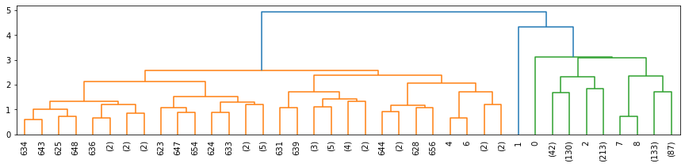

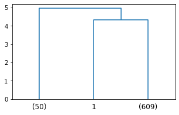

```python
#find copenet score and dendogram
datalink = linkage(creditdata_scale, 'weighted', metric='euclidean')
datalink_coph=cophenet(datalink,pdist(creditdata_scale))[0]
print('cophenet',datalink_coph)
plt.figure(figsize=(15, 3))
dendrogram(datalink,leaf_rotation=90.0,p=5,leaf_font_size=10,truncate_mode='level')
plt.show()
plt.figure(figsize=(5, 3))
dendrogram(datalink,truncate_mode='lastp',p=3)
plt.show()
```

```
array([[<matplotlib.axes._subplots.AxesSubplot object at 0x000001AE80074B80>,
      dtype=object)
```

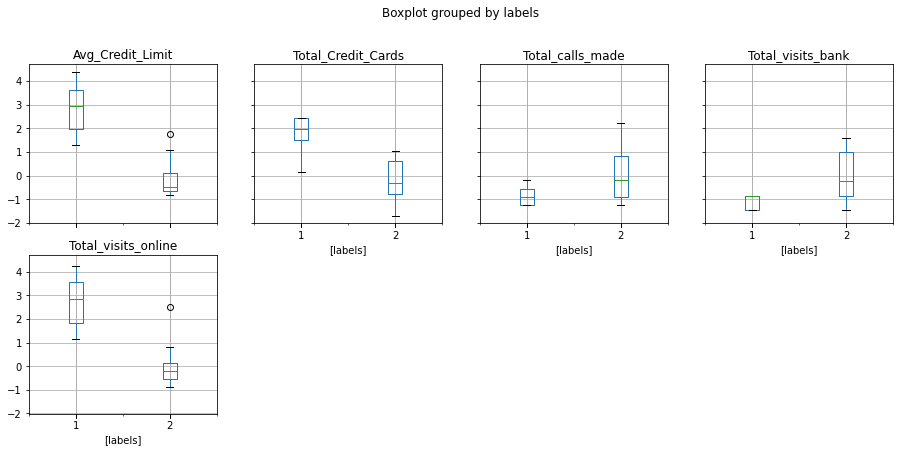

```python
#analyse using box plot
from scipy.cluster.hierarchy import fcluster
max_d = 4
labels_h = fcluster(datalink_a, max_d, criterion='distance')
#print('labels_h',labels_h)
## creating a new dataframe only for labels and converting it into categorical variable
df_labels_h = pd.DataFrame(labels_h , columns = list(['labels']))
df_labels_h['labels'] = df_labels_h['labels'].astype('category')
# Joining the label dataframe with the scaled data frame.
df_labeled_h = creditdata_scale.join(df_labels_h)
#df_labeled_h.head(5)
# Joining the label dataframe with the original data frame.
df_labeled_orig_h = creditdata.join(df_labels_h)
#df_labeled_orig_h.head(5)
df_labeled_h['labels'].value_counts()
df_labeled_h.boxplot(by = 'labels',  layout=(3,4), figsize=(15, 10))
```

```python
silhouette_s=silhouette_score(creditdata_scale,labels_h)
print('silhouette_s',silhouette_s)
df_labeled_orig_h.groupby('labels').mean()
```

```
silhouette_s 0.5703183487340514
```

| labels | Avg_Credit_Limit | Total_Credit_Cards | Total_visits_bank | Total_visits_online | Total_calls_made |
| --- | --- | --- | --- | --- | --- |
| 1 | 141040.000000 | 8.74000 | 0.60000 | 10.90000 | 1.080000 |
| 2 | 25847.540984 | 4.37541 | 2.55082 | 1.92623 | 3.788525 |

#### Observation : the spending behaviour between the 2 groups has a huge gap ,2 clusters may not be a good option

### Linkage by centroid method

```
cophenet 0.8939385846326323
```

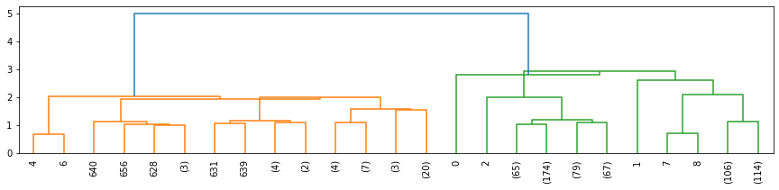

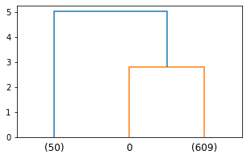

```python
#find copenet score and dendogram
datalink = linkage(creditdata_scale, 'centroid', metric='euclidean')
datalink_coph=cophenet(datalink,pdist(creditdata_scale))[0]
print('cophenet',datalink_coph)
plt.figure(figsize=(15, 3))
dendrogram(datalink,leaf_rotation=90.0,p=5,leaf_font_size=10,truncate_mode='level')
plt.show()
plt.figure(figsize=(5, 3))
dendrogram(datalink,truncate_mode='lastp',p=3)
plt.show()
```

```python
#analyse using box plot
from scipy.cluster.hierarchy import fcluster
max_d = 3
labels_h = fcluster(datalink_a, max_d, criterion='distance')
labels_h
## creating a new dataframe only for labels and converting it into categorical variable
df_labels_h = pd.DataFrame(labels_h , columns = list(['labels']))
df_labels_h['labels'] = df_labels_h['labels'].astype('category')
# Joining the label dataframe with the scaled data frame.
df_labeled_h = creditdata_scale.join(df_labels_h)
#df_labeled_h.head(5)
# Joining the label dataframe with the original data frame.
df_labeled_orig_h = creditdata.join(df_labels_h)
#df_labeled_orig_h.head(5)
df_labeled_h['labels'].value_counts()
df_labeled_h.boxplot(by = 'labels',  layout=(3,4), figsize=(15, 10))
```

```
array([[<matplotlib.axes._subplots.AxesSubplot object at 0x000001AE819B9280>,
      dtype=object)
```

```python
silhouette_s=silhouette_score(creditdata_scale,labels_h)
print('silhouette_s',silhouette_s)
df_labeled_orig_h.groupby('labels').mean()
```

```
silhouette_s 0.47495143595793504
```

| labels | Avg_Credit_Limit | Total_Credit_Cards | Total_visits_bank | Total_visits_online | Total_calls_made |
| --- | --- | --- | --- | --- | --- |
| 1 | 141040.000000 | 8.740000 | 0.600000 | 10.900000 | 1.080000 |
| 2 | 12197.309417 | 2.403587 | 0.928251 | 3.560538 | 6.883408 |
| 3 | 33541.450777 | 5.520725 | 3.492228 | 0.984456 | 2.010363 |
| 4 | 100000.000000 | 2.000000 | 1.000000 | 1.000000 | 0.000000 |

### Linkage by median method

```
cophenet 0.8893799537016724
```

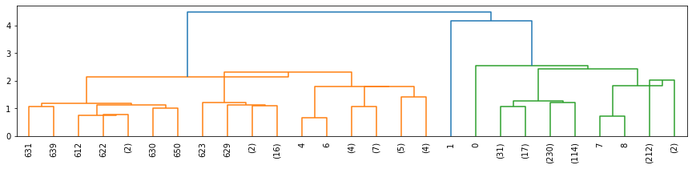

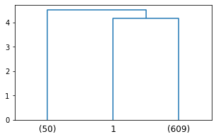

```python
#find copenet score and dendogram
datalink = linkage(creditdata_scale, 'median', metric='euclidean')
datalink_coph=cophenet(datalink,pdist(creditdata_scale))[0]
print('cophenet',datalink_coph)
plt.figure(figsize=(15, 3))
dendrogram(datalink,leaf_rotation=90.0,p=5,leaf_font_size=10,truncate_mode='level')
plt.show()
plt.figure(figsize=(5, 3))
dendrogram(datalink,truncate_mode='lastp',p=3)
plt.show()
```

```
array([[<matplotlib.axes._subplots.AxesSubplot object at 0x000001AE824715B0>,
      dtype=object)
```

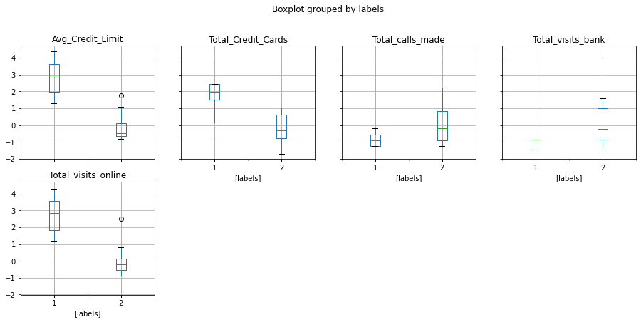

```python
#analyse using box plot
from scipy.cluster.hierarchy import fcluster
max_d = 4
labels_h = fcluster(datalink_a, max_d, criterion='distance')
labels_h
## creating a new dataframe only for labels and converting it into categorical variable
df_labels_h = pd.DataFrame(labels_h , columns = list(['labels']))
df_labels_h['labels'] = df_labels_h['labels'].astype('category')
# Joining the label dataframe with the scaled data frame.
df_labeled_h = creditdata_scale.join(df_labels_h)
#df_labeled_h.head(5)
# Joining the label dataframe with the original data frame.
df_labeled_orig_h = creditdata.join(df_labels_h)
#df_labeled_orig_h.head(5)
df_labeled_h['labels'].value_counts()
df_labeled_h.boxplot(by = 'labels',  layout=(3,4), figsize=(15, 10))
```

```python
silhouette_s=silhouette_score(creditdata_scale,labels_h)
print('silhouette_s',silhouette_s)
```

```
silhouette_s 0.5703183487340514
```

#### Observation : the spending behaviour between the 2 groups has a huge gap ,2 clusters may not be a good option

### Out of all the methods ,average method has high copenet score and data seems to be distributed better

### Hierarchical clustering using Average method

```
cophenet 0.8977080867389372
```

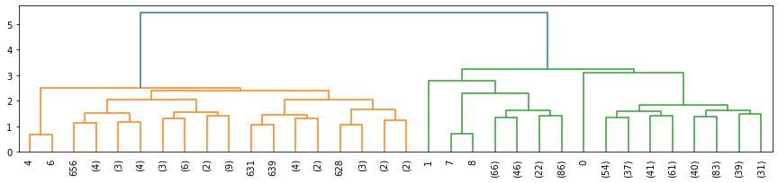

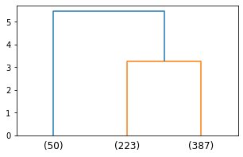

```python
#find copenet score and dendogram
datalink = linkage(creditdata_scale, 'average', metric='euclidean')
datalink_coph=cophenet(datalink,pdist(creditdata_scale))[0]
print('cophenet',datalink_coph)
plt.figure(figsize=(15, 3))
dendrogram(datalink,leaf_rotation=90.0,p=5,leaf_font_size=10,truncate_mode='level')
plt.show()
plt.figure(figsize=(5, 3))
dendrogram(datalink,truncate_mode='lastp',p=3)
plt.show()
```

```python
#analyse using box plot
from scipy.cluster.hierarchy import fcluster
max_d = 3
labels_h = fcluster(datalink_a, max_d, criterion='distance')
labels_h
## creating a new dataframe only for labels and converting it into categorical variable
df_labels_h = pd.DataFrame(labels_h , columns = list(['labels']))
df_labels_h['labels'] = df_labels_h['labels'].astype('category')
# Joining the label dataframe with the scaled data frame.
df_labeled_h = creditdata_scale.join(df_labels_h)
#df_labeled_h.head(5)
# Joining the label dataframe with the original data frame.
df_labeled_orig_h = creditdata.join(df_labels_h)
#df_labeled_orig_h.head(5)
df_labeled_h['labels'].value_counts()

df_labeled_h.boxplot(by = 'labels',  layout=(3,4), figsize=(15, 10))
```

```
array([[<matplotlib.axes._subplots.AxesSubplot object at 0x000001AE80052790>,
      dtype=object)
```

```python
silhouette_s=silhouette_score(creditdata_scale,labels_h)
print('silhouette_s',silhouette_s)
df_labeled_orig_h.groupby('labels').mean()
```

```
silhouette_s 0.47495143595793504
```

| labels | Avg_Credit_Limit | Total_Credit_Cards | Total_visits_bank | Total_visits_online | Total_calls_made |
| --- | --- | --- | --- | --- | --- |
| 1 | 141040.000000 | 8.740000 | 0.600000 | 10.900000 | 1.080000 |
| 2 | 12197.309417 | 2.403587 | 0.928251 | 3.560538 | 6.883408 |
| 3 | 33541.450777 | 5.520725 | 3.492228 | 0.984456 | 2.010363 |
| 4 | 100000.000000 | 2.000000 | 1.000000 | 1.000000 | 0.000000 |

### Observations :

Cluster 1 is characterised by high credit limit , high # of credit cards, low bank visit ,high online visit , low calls

Cluster 2 is characterised by low credit limit , low # of credit cards, low bank visit , medium online visit , high calls

Cluster 3 is characterised by medium credit limit , medium # of credit cards, high bank visit , low online visit , medium calls

Cluster 4 is characterised by high credit limit , low # of credit cards, medium bank visit , low online visit , low calls

### Key Questions:

1) How many different segments of customers are there?

```
 There are 4 segment of customers
 cluster 1--high spending & high # of credit cards
 cluster 2--low spending & low # of credit cards
 cluster 3--medium spending & medium # of credit cards
 cluster 4--high spending & low # of credit cards
```

2) How are these segments different from each other?

```
 Segemnts are differnt based on there spending behaviour ,number of credit cards  and communications to bank .
```

3) What are your recommendations to the bank on how to better market to and service these customers?

```
 Cluster 1 -- loyalty programs may help bank to keep these customers for long time ,means of marketing is thru online
 Cluster 2 -- Bank can provide new offer so customers in this segment use the credit card more often on purchases ,use  phone calls as means of marketing.
 Cluster 3 --May be a cash back will encourage these segement of customers to use credit card more ,marketing can be
 done  when they visit bank.
 Cluster 4 -- loyalty programs may help bank to keep these customers for long time ,marketing can be
 done  when they visit bank
```